# Predicting Student Grades

Research Questions:

1. Are the different grades correlated (Does a high grade in subject mean high grades in other subjects)
2. Which variables are important for determining the scores of each subject (Reading, Writing, Math)
3. Is it possible to make a model that will successfully predict grades

https://www.kaggle.com/datasets/daviddraper1518/predicting-student-grades/data

## Challenge Goals

Advanced Machine Learning:

Statistical Hypothesis Testing

1. Significance tests, comparing MSE of various tests will give us an understanding of which variable is the better indicator.

## Collaboration and Conduct

Students are expected to follow Washington state law on the [Student Conduct Code for the University of Washington](https://www.washington.edu/admin/rules/policies/WAC/478-121TOC.html). In this course, students must:

- Indicate on your submission any assistance received, including materials distributed in this course.
- Not receive, generate, or otherwise acquire any substantial portion or walkthrough to an assessment.
- Not aid, assist, attempt, or tolerate prohibited academic conduct in others.

Update the following code cell to include your name and list your sources. If you used any kind of computer technology to help prepare your assessment submission, include the queries and/or prompts. Submitted work that is not consistent with sources may be subject to the student conduct process.

```python
your_name = "Aldrai Batsuren, Shunya Kodaira, Chaz Roe"
sources = [
    "https://courses.cs.washington.edu/courses/cse163/25sp/2025/05/05/learning-algorithms/",
    "https://courses.cs.washington.edu/courses/cse163/25sp/2025/05/07/model-evaluation/",
    "https://courses.cs.washington.edu/courses/cse163/25sp/2025/04/23/data-settings/",
    "https://courses.cs.washington.edu/courses/cse163/25sp/2025/04/21/data-visualization/",
    "https://courses.cs.washington.edu/courses/cse163/25sp/2025/04/24/groupby-and-data-viz/",
    "https://courses.cs.washington.edu/courses/cse163/25sp/2025/05/02/asymptotic-analysis/"
]

assert your_name != "", "your_name cannot be empty"
assert ... not in sources, "sources should not include the placeholder ellipsis"
assert len(sources) >= 6, "must include at least 6 sources, inclusive of lectures and sections"
```

## Data Setting and Methods

Imported the dataset, and created the letter_to_num() function to change the grades from letters to numbers and return that data. The final variables in the cell we applied functions to columns, with Writing, Reading, and Math.

```python
import pandas as pd

AllResults = pd.read_csv("AllResults.csv").dropna()

def letter_to_num(data, subject):
    """
    Given a subject and the dataset, changes the letter grades
    into a predetermined numerical scale
    """
    grade_dict = {"N": 0, "B": 1, "2": 2, "3C": 3, "3B": 4,
                  "3": 5, "3A": 6, "4C": 7, "4B": 8, "4": 9,
                  "4A": 10, "5C": 11, "5B": 12, "5": 13,
                  "5A": 14, "6C": 15, "6B": 16, "6": 17, "6A": 18}
    for grade, score in grade_dict.items():
        data.loc[data[subject] == grade, subject] = score
    data[subject] = pd.to_numeric(data[subject])
    return data

AllResults = letter_to_num(AllResults, "Re")
AllResults = letter_to_num(AllResults, "Wr")
AllResults = letter_to_num(AllResults, "Ma")
```

Q. Are the different grades correlated (Does a high grade in subject mean high grades in other subjects)

```
          Re        Wr        Ma
Re  1.000000  0.644544  0.637746
Wr  0.644544  1.000000  0.588506
Ma  0.637746  0.588506  1.000000
```

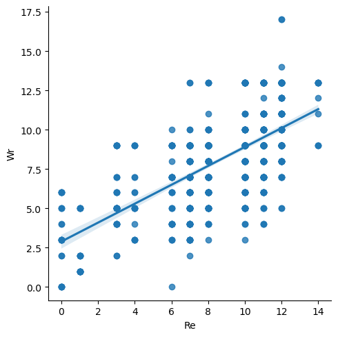

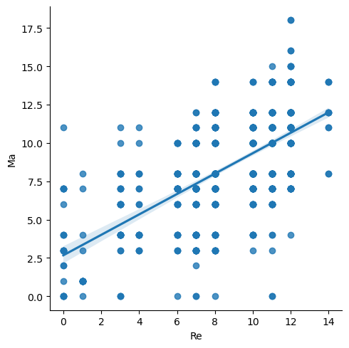

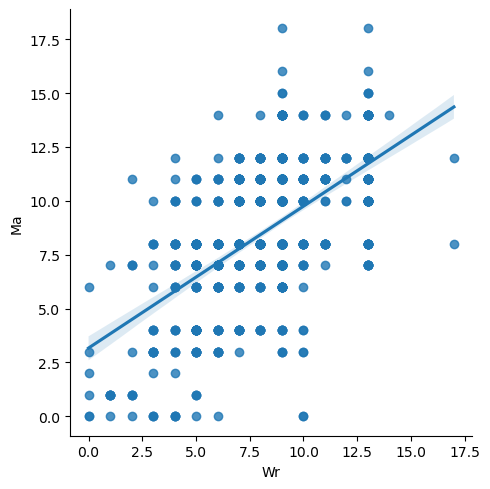

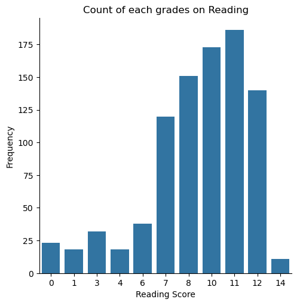

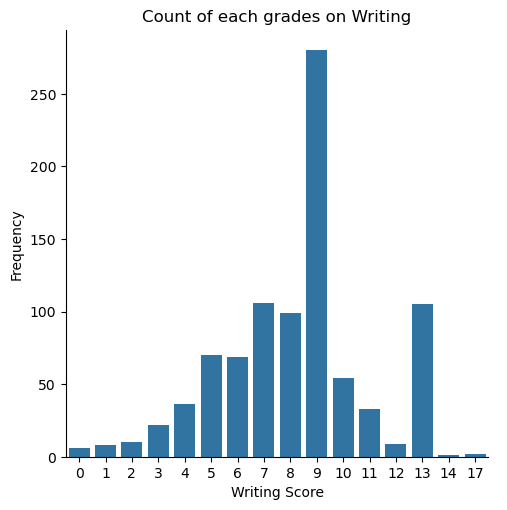

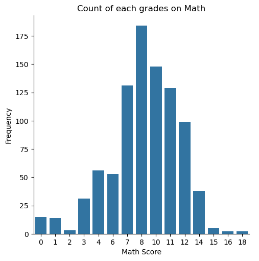

```python
import seaborn as sns


"""Scatterplots of subject vs subject"""
sns.lmplot(AllResults, x = "Re", y = "Wr")
sns.lmplot(AllResults, x = "Re", y = "Ma")
sns.lmplot(AllResults, x = "Wr", y = "Ma")


"""Bar graph"""
Re_grid = sns.catplot(AllResults, x = "Re", kind = "count")
Re_grid.set(title = "Count of each grades on Reading",
            xlabel = "Reading Score", ylabel = "Frequency")
Wr_grid = sns.catplot(AllResults, x = "Wr", kind = "count")
Wr_grid.set(title = "Count of each grades on Writing",
            xlabel = "Writing Score", ylabel = "Frequency")
Ma_grid = sns.catplot(AllResults, x = "Ma", kind = "count")
Ma_grid.set(title = "Count of each grades on Math",
            xlabel = "Math Score", ylabel = "Frequency")

"""Correlation plot of the scores"""
print(AllResults[["Re", "Wr", "Ma"]].corr())
```

```
Model: 1.43 + 0.30(Re)
Error: 2.5988767568300344
Model: 1.49 + 0.32(Wr)
Error: 2.624346672160591
Model: 0.24 + 0.40(Ma)
Error: 2.0917149644285304
```

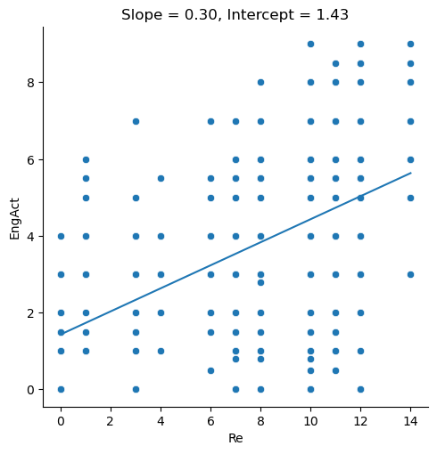

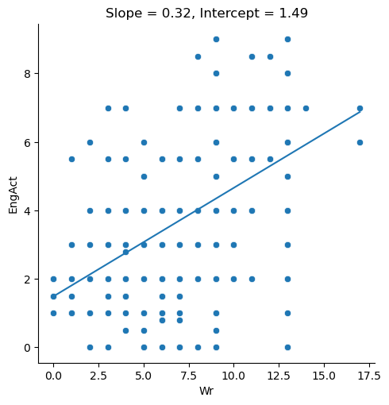

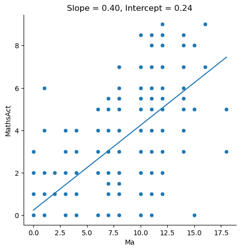

```python
from sklearn.linear_model import LinearRegression
from sklearn.metrics import mean_squared_error
def plot_line(feature, target, slope, intercept=0):
    grid = sns.relplot(AllResults, x = feature, y = target)
    max_x = AllResults[feature].max()
    min_x = AllResults[feature].min()

    grid.facet_axis(0, 0).plot([min_x, max_x], [intercept + slope * min_x, intercept + slope * max_x])
    grid.set(title=f"Slope = {slope:.2f}, Intercept = {intercept:.2f}")
    return grid

def linearReg(feature, target):
    X = AllResults[[feature]]
    y = AllResults[target]
    reg = LinearRegression().fit(X, y)

    print("Model:", " + ".join([f"{reg.intercept_:.2f}"] + [f"{coef:.2f}({X.columns[i]})" for i, coef in enumerate(reg.coef_)]))
    print("Error:", mean_squared_error(y, reg.predict(X)))

    plot_line(feature, target, reg.coef_[0], reg.intercept_)

linearReg("Re", "EngAct")
linearReg("Wr", "EngAct")
linearReg("Ma", "MathsAct")
```

Analysis: All 3 scatter plots indicate a positive, moderate correlation between each of the subjects. With a correlation coefficient of 0.55-0.65 for all relationships between the subjects, there is evidence of a potential sign that there exists a correlation between the subjects.

Q. Which variables are important/not important for determining the grades of each subject (Reading, and Math test scores)

Our dataset provides the following variables Regressor variables PP - The pupil premium is additional funding for publicly funded schools in England. EAL - English as an additional language. (0 for False, 1 for True) SEN - Special education needs. (0 for False, 1 for True) Re - Reading grades from age 10 Wr - Writing grades from age 10 Ma - Math grades from age 10 Response variables EngAct - Current grade in English MathsAct - Current grade in Math Given the variables above, we want to test whether the 6 regressors are important/useful in estimating the English/Math grades. For this test, the following assumptions will be made Samples follow a normal distribution (Met by the law of large numbers, n = 910) Independence, which is met given the nature of grades and how they are affected by the individual. Random Sampling Equal variances across the variables With the above requirements in mind, our hypothesis test will be the following (with alpha = 0.05) H0: All coefficients of variables = 0 H1: At least one coefficient is not 0

```python
# for English grades
from sklearn.linear_model import LinearRegression
from sklearn.model_selection import train_test_split
from sklearn.metrics import mean_squared_error

x = AllResults[["PP", "EAL", "SEN", "Re", "Wr", "Ma"]]
y = AllResults["EngAct"]

x_train, x_test, y_train, y_test = train_test_split(x, y, test_size = 0.2)

model = LinearRegression().fit(x_train, y_train)
print(pd.Series(model.coef_))
regr_coords = LinearRegression().fit(x_train, y_train)
y_predict = regr_coords.predict(x_test)
print("MSE:", mean_squared_error(y_test, y_predict))
```

```
0   -0.709916
1    0.588968
2   -0.242047
3    0.146013
4    0.143840
5    0.055240
dtype: float64
MSE: 2.495446279517149
```

```python
import statsmodels.api as sm


x_train = sm.add_constant(x_train)
model = sm.OLS(y_train, x_train).fit()
print(model.summary())
```

```
                            OLS Regression Results
==============================================================================
Dep. Variable:                 EngAct   R-squared:                       0.323
Model:                            OLS   Adj. R-squared:                  0.317
Method:                 Least Squares   F-statistic:                     57.23
Date:                Tue, 10 Jun 2025   Prob (F-statistic):           7.12e-58
Time:                        06:51:18   Log-Likelihood:                -1326.4
No. Observations:                 728   AIC:                             2667.
Df Residuals:                     721   BIC:                             2699.
Df Model:                           6
Covariance Type:            nonrobust
==============================================================================
                 coef    std err          t      P>|t|      [0.025      0.975]
------------------------------------------------------------------------------
const          1.3248      0.225      5.898      0.000       0.884       1.766
PP            -0.7099      0.120     -5.915      0.000      -0.946      -0.474
EAL            0.5890      0.196      3.001      0.003       0.204       0.974
SEN           -0.2420      0.137     -1.766      0.078      -0.511       0.027
Re             0.1460      0.027      5.450      0.000       0.093       0.199
Wr             0.1438      0.028      5.222      0.000       0.090       0.198
Ma             0.0552      0.024      2.302      0.022       0.008       0.102
==============================================================================
Omnibus:                        7.808   Durbin-Watson:                   2.025
Prob(Omnibus):                  0.020   Jarque-Bera (JB):               11.364
Skew:                          -0.002   Prob(JB):                      0.00341
Kurtosis:                       3.612   Cond. No.                         67.5
==============================================================================

Notes:
[1] Standard Errors assume that the covariance matrix of the errors is correctly specified.
```

```python
# for Math grades
x = AllResults[["PP", "EAL", "SEN", "Re", "Wr", "Ma"]]
y = AllResults["MathsAct"]


x_train, x_test, y_train, y_test = train_test_split(x, y, test_size = 0.2)


model = LinearRegression().fit(x_train, y_train)
print(pd.Series(model.coef_))


regr_coords = LinearRegression().fit(x_train, y_train)


y_predict = regr_coords.predict(x_test)
print("MSE:", mean_squared_error(y_test, y_predict))
```

```
0   -0.635744
1    1.023391
2   -0.422481
3    0.032952
4    0.016199
5    0.344273
dtype: float64
MSE: 1.8150817565233857
```

```python
x_train = sm.add_constant(x_train)
model = sm.OLS(y_train, x_train).fit()
print(model.summary())
```

```
                            OLS Regression Results
==============================================================================
Dep. Variable:               MathsAct   R-squared:                       0.488
Model:                            OLS   Adj. R-squared:                  0.484
Method:                 Least Squares   F-statistic:                     114.5
Date:                Tue, 10 Jun 2025   Prob (F-statistic):          2.69e-101
Time:                        06:51:18   Log-Likelihood:                -1260.5
No. Observations:                 728   AIC:                             2535.
Df Residuals:                     721   BIC:                             2567.
Df Model:                           6
Covariance Type:            nonrobust
==============================================================================
                 coef    std err          t      P>|t|      [0.025      0.975]
------------------------------------------------------------------------------
const          0.5099      0.207      2.464      0.014       0.104       0.916
PP            -0.6357      0.108     -5.865      0.000      -0.849      -0.423
EAL            1.0234      0.179      5.713      0.000       0.672       1.375
SEN           -0.4225      0.124     -3.410      0.001      -0.666      -0.179
Re             0.0330      0.025      1.314      0.189      -0.016       0.082
Wr             0.0162      0.025      0.639      0.523      -0.034       0.066
Ma             0.3443      0.022     15.588      0.000       0.301       0.388
==============================================================================
Omnibus:                       11.102   Durbin-Watson:                   1.896
Prob(Omnibus):                  0.004   Jarque-Bera (JB):               18.349
Skew:                          -0.008   Prob(JB):                     0.000104
Kurtosis:                       3.778   Cond. No.                         67.3
==============================================================================

Notes:
[1] Standard Errors assume that the covariance matrix of the errors is correctly specified.
```

```
Model: 1.43 + 0.30(Re)
Error: 2.5988767568300344
Model: 1.49 + 0.32(Wr)
Error: 2.624346672160591
Model: 0.24 + 0.40(Ma)
Error: 2.0917149644285304
```

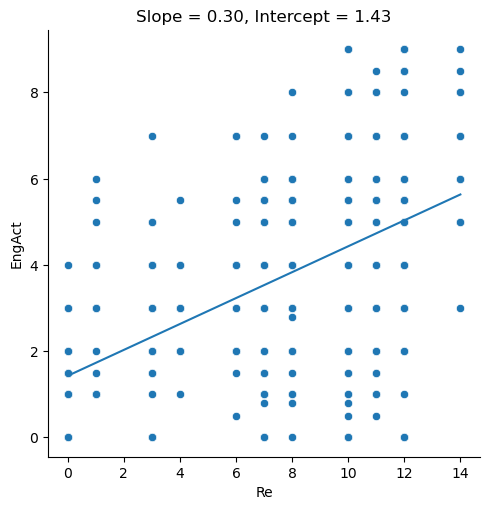

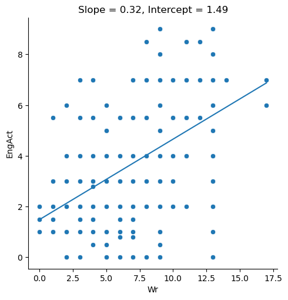

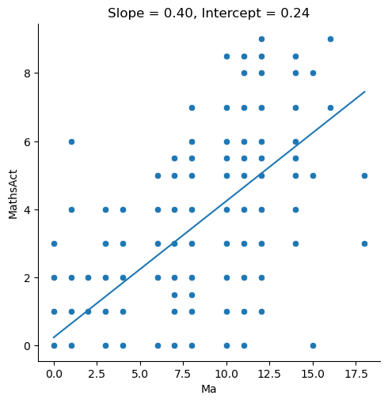

```python
def plot_line(feature, target, slope, intercept=0):
    grid = sns.relplot(AllResults, x = feature, y = target)
    max_x = AllResults[feature].max()
    min_x = AllResults[feature].min()

    grid.facet_axis(0, 0).plot([min_x, max_x], [intercept + slope * min_x, intercept + slope * max_x])
    grid.set(title=f"Slope = {slope:.2f}, Intercept = {intercept:.2f}")
    return grid

def linearReg(feature, target):
    X = AllResults[[feature]]
    y = AllResults[target]
    reg = LinearRegression().fit(X, y)

    print("Model:", " + ".join([f"{reg.intercept_:.2f}"] + [f"{coef:.2f}({X.columns[i]})" for i, coef in enumerate(reg.coef_)]))
    print("Error:", mean_squared_error(y, reg.predict(X)))

    plot_line(feature, target, reg.coef_[0], reg.intercept_)

linearReg("Re", "EngAct")
linearReg("Wr", "EngAct")
linearReg("Ma", "MathsAct")
```